# Práctica R

Carmen Amenedo Peñamaría

2026-10-29

# Ejercicio 1

Leer el fichero `comptagevelo2017.csv` como un dataframe.

```r
library(tidyverse)
library(lubridate)

comptage <- read_csv("comptagevelo2017.csv")
```

```
## ──────────────────────────────────────────────────────── Delimiter: "," chr
## (1): Date dbl (19): Berri1, Boyer, Boyer 2, Brébeuf, Christophe-Colomb, CSC
## (Côte Sai... time (1): ...2
```

# Ejercicio 2

Eliminar la columna 2 del dataframe.

```r
comptage <- comptage %>%
  select(-2)
```

# Ejercicio 3

Transformar el dataframe para que cada columna represente una única variable.

```r
comptage <- comptage %>%
  pivot_longer(
    cols = -Date,
    names_to = "distrito",
    values_to = "ciclistas"
  )
```

# Ejercicio 4

Crear tres nuevas variables con la información del día, mes y año, manteniendo la columna `Date`.

```r
comptage <- comptage %>%
  mutate(
    dia = day(dmy(Date)),
    mes = month(dmy(Date)),
    anio = year(dmy(Date))
  )
```

# Ejercicio 5

Convertir la columna `Date` a tipo fecha.

```r
comptage <- comptage %>%
  mutate(Date = dmy(Date))
```

# Ejercicio 6

Eliminar los espacios alrededor de “/” en los nombres de los distritos.

```r
comptage <- comptage %>%
  mutate(
    distrito = str_replace_all(distrito, "\\s*/\\s*", "/")
  )
```

# Ejercicio 7

Calcular el porcentaje de días en los que faltan datos para cada distrito.

```r
missing_distrito <- comptage %>%
  group_by(distrito) %>%
  summarise(
    porcentaje_missing = mean(is.na(ciclistas)) * 100
  )

missing_distrito
```

```
## # A tibble: 19 × 2
##    distrito                    porcentaje_missing
##    <chr>                                    <dbl>
##  1 Berri1                                   0
##  2 Boyer                                    0
##  3 Boyer 2                                  0.548
##  4 Brébeuf                                  0
##  5 CSC (Côte Sainte-Catherine)              0
##  6 Christophe-Colomb                       11.8
##  7 Eco-Totem - Métro Laurier                0
##  8 Maisonneuve_2                            0
##  9 Maisonneuve_3                            0
## 10 Notre-Dame                               0
## 11 Parc                                     0
## 12 PierDup                                  0
## 13 Pont Jacques-Cartier                    20.3
## 14 Rachel/Hôtel de Ville                    0
## 15 Rachel/Papineau                          0
## 16 René-Lévesque                            0
## 17 Saint-Antoine                            0
## 18 Saint-Laurent/Bellechasse                0
## 19 Saint-Urbain                             0
```

# Ejercicio 8

Calcular el total de ciclistas que pasa por cada distrito a lo largo del año.

```r
total_distrito <- comptage %>%
  group_by(distrito) %>%
  summarise(
    total_ciclistas = sum(ciclistas, na.rm = TRUE)
  )

total_distrito
```

```
## # A tibble: 19 × 2
##    distrito                    total_ciclistas
##    <chr>                                 <dbl>
##  1 Berri1                               924499
##  2 Boyer                                635273
##  3 Boyer 2                              470098
##  4 Brébeuf                              786729
##  5 CSC (Côte Sainte-Catherine)          449665
##  6 Christophe-Colomb                    204327
##  7 Eco-Totem - Métro Laurier            596706
##  8 Maisonneuve_2                        862718
##  9 Maisonneuve_3                        361726
## 10 Notre-Dame                           354063
## 11 Parc                                 593997
## 12 PierDup                              309569
## 13 Pont Jacques-Cartier                 271545
## 14 Rachel/Hôtel de Ville                750977
## 15 Rachel/Papineau                     1047434
## 16 René-Lévesque                        357136
## 17 Saint-Antoine                        106950
## 18 Saint-Laurent/Bellechasse           1483908
## 19 Saint-Urbain                         371084
```

# Ejercicio 9

Obtener los cinco distritos con mayor número de ciclistas.

```r
top5_distritos <- total_distrito %>%
  arrange(desc(total_ciclistas)) %>%
  slice_head(n = 5)

top5_distritos
```

```
## # A tibble: 5 × 2
##   distrito                  total_ciclistas
##   <chr>                               <dbl>
## 1 Saint-Laurent/Bellechasse         1483908
## 2 Rachel/Papineau                   1047434
## 3 Berri1                             924499
## 4 Maisonneuve_2                      862718
## 5 Brébeuf                            786729
```

Los cinco distritos con más ciclistas son Saint-Laurent/Bellechasse, Rachel/Papineau, Berri1, Maisonneuve_2 y Brébeuf.

# Ejercicio 10

Realizar un gráfico de barras horizontales del total de ciclistas por distrito.

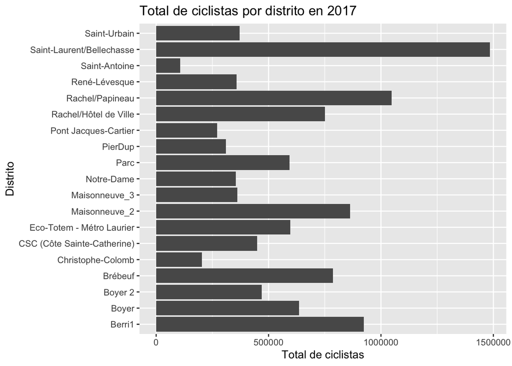

```r
ggplot(
  total_distrito,
  aes(x = total_ciclistas, y = distrito)
) +
  geom_col() +
  labs(
    x = "Total de ciclistas",
    y = "Distrito",
    title = "Total de ciclistas por distrito en 2017"
  )
```

# Ejercicio 11

Realizar un gráfico de líneas con la evolución mensual de ciclistas para cada distrito.

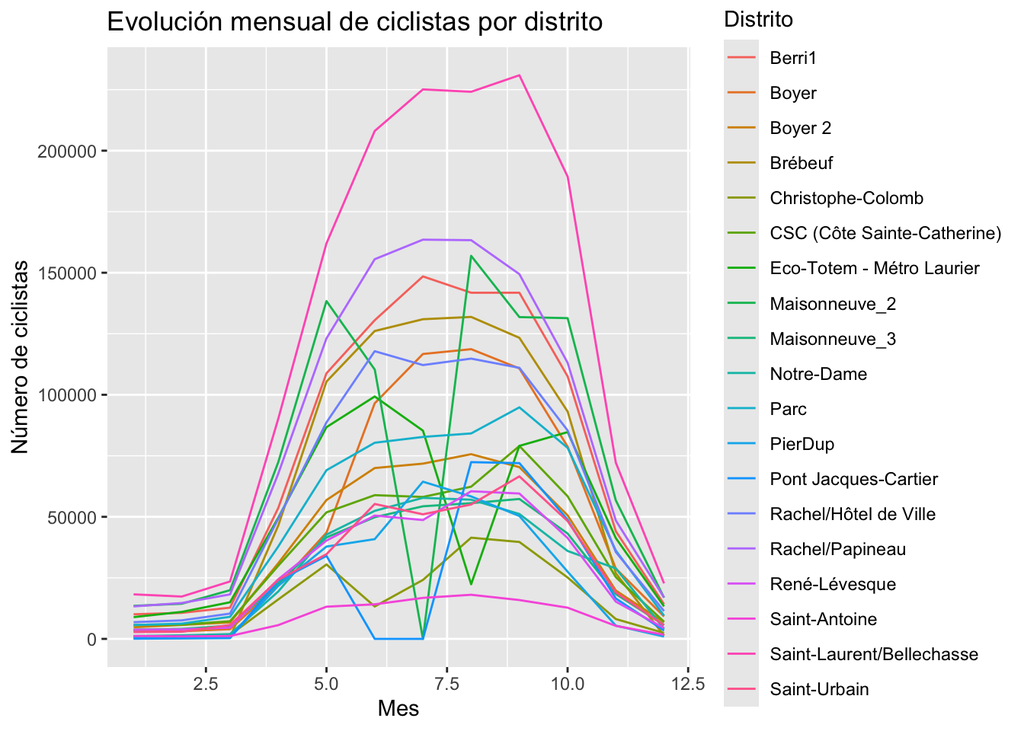

```r
mensual_distrito <- comptage %>%
  group_by(distrito, mes) %>%
  summarise(
    total_ciclistas = sum(ciclistas, na.rm = TRUE),
    .groups = "drop"
  )

ggplot(
  mensual_distrito,
  aes(
    x = mes,
    y = total_ciclistas,
    color = distrito,
    group = distrito
  )
) +
  geom_line() +
  labs(
    x = "Mes",
    y = "Número de ciclistas",
    color = "Distrito",
    title = "Evolución mensual de ciclistas por distrito"
  )
```

# Ejercicio 12

Ordenar las barras del gráfico de mayor a menor según el número de ciclistas.

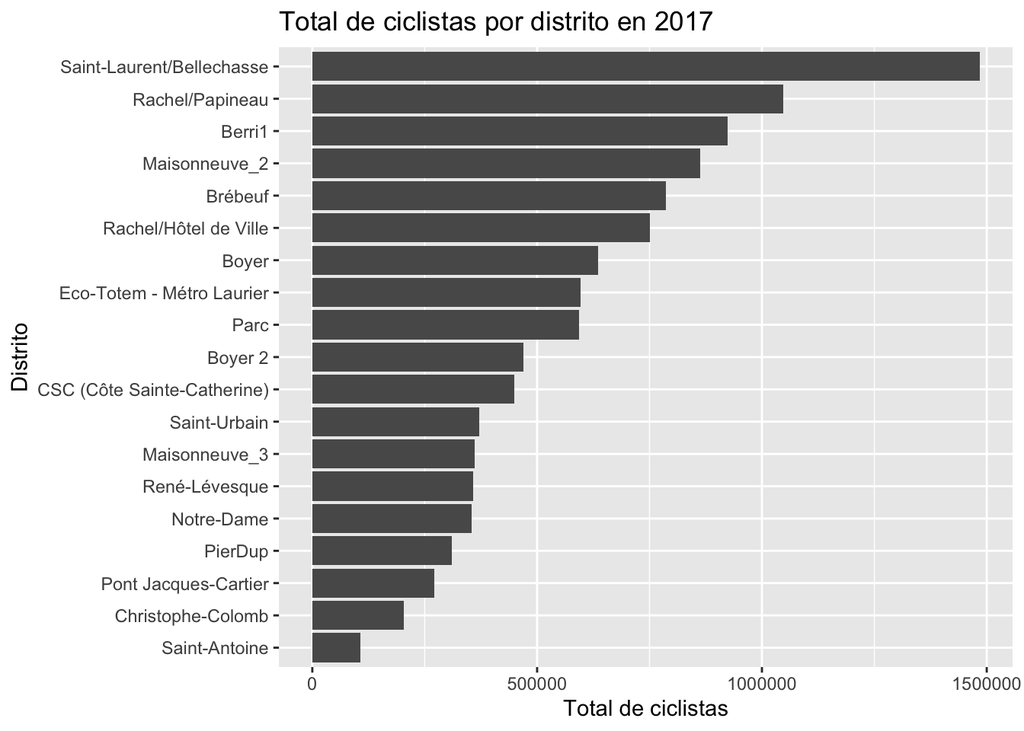

```r
ggplot(
  total_distrito,
  aes(
    x = total_ciclistas,
    y = reorder(distrito, total_ciclistas)
  )
) +
  geom_col() +
  labs(
    x = "Total de ciclistas",
    y = "Distrito",
    title = "Total de ciclistas por distrito en 2017"
  )
```

# Ejercicio 13

Añadir al gráfico mensual una línea azul y más ancha con la media de ciclistas por mes.

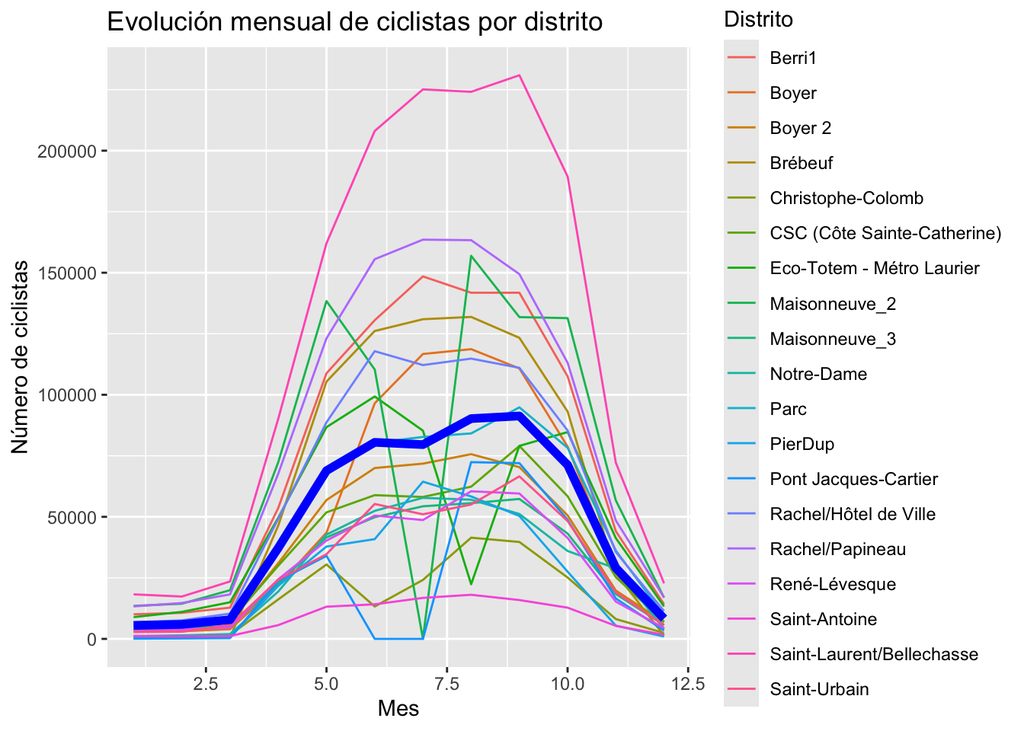

```r
media_mensual <- mensual_distrito %>%
  group_by(mes) %>%
  summarise(
    media_ciclistas = mean(total_ciclistas, na.rm = TRUE)
  )

ggplot(
  mensual_distrito,
  aes(
    x = mes,
    y = total_ciclistas,
    color = distrito,
    group = distrito
  )
) +
  geom_line() +
  geom_line(
    data = media_mensual,
    aes(
      x = mes,
      y = media_ciclistas
    ),
    inherit.aes = FALSE,
    color = "blue",
    linewidth = 2
  ) +
  labs(
    x = "Mes",
    y = "Número de ciclistas",
    color = "Distrito",
    title = "Evolución mensual de ciclistas por distrito"
  )
```

# Ejercicio 14

Realizar un gráfico de barras del número de ciclistas para cada día de la semana en los cinco distritos con más ciclistas.

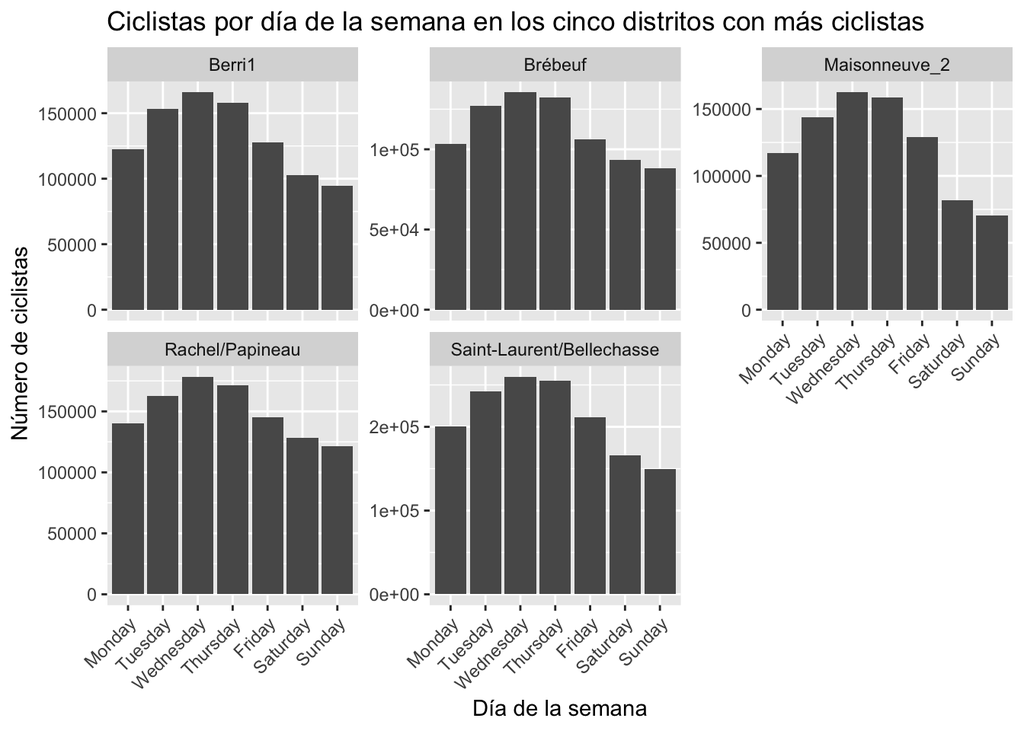

```r
comptage <- comptage %>%
  mutate(
    dia_semana = wday(
      Date,
      label = TRUE,
      abbr = FALSE,
      week_start = 1
    )
  )

semana_top5 <- comptage %>%
  filter(distrito %in% top5_distritos$distrito) %>%
  group_by(distrito, dia_semana) %>%
  summarise(
    total_ciclistas = sum(ciclistas, na.rm = TRUE),
    .groups = "drop"
  )

ggplot(
  semana_top5,
  aes(x = dia_semana, y = total_ciclistas)
) +
  geom_col() +
  facet_wrap(~ distrito, scales = "free_y") +
  labs(
    x = "Día de la semana",
    y = "Número de ciclistas",
    title = "Ciclistas por día de la semana en los cinco distritos con más ciclistas"
  ) +
  theme(
    axis.text.x = element_text(angle = 45, hjust = 1)
  )
```

# Ejercicio 15

Completar los valores missing con la media de ciclistas agrupada por distrito y mes.

```r
comptage <- comptage %>%
  group_by(distrito, mes) %>%
  mutate(
    ciclistas = if_else(
      is.na(ciclistas),
      mean(ciclistas, na.rm = TRUE),
      ciclistas
    )
  ) %>%
  ungroup()

sum(is.na(comptage$ciclistas))
```

```
## [1] 61
```

Quedan 61 valores missing correspondientes a Pont Jacques-Cartier en los meses de junio y julio. En estos grupos todos los valores son missing, por lo que no existe ninguna observación disponible con la que calcular la media del distrito y mes.

# Ejercicio 16

Leer el fichero `localisationcompteursvelo2015.csv` utilizando la codificación ISO-8859-1.

```r
localizacion <- read_csv(
  "localisationcompteursvelo2015.csv",
  locale = locale(encoding = "ISO-8859-1")
)
glimpse(localizacion)
```

```
## Rows: 21
## Columns: 8
## $ id             <dbl> 1, 2, 4, 5, 6, 7, 8, 10, 12, 14, 15, 17, 19, 22, 23, 29…
## $ nom            <chr> "St-Urbain_1", "Brebeuf_1", "Maisonneuve_1", "Maisonneu…
## $ nom_comptage   <chr> "Saint-Urbain", "Brébeuf", "Maisonneuve_1", "Maisonneuv…
## $ Etat           <chr> "Existant", "Existant", "À réinstaller", "Existant", "E…
## $ Type           <chr> "compteur", "compteur", "compteur", "compteur", "compte…
## $ Annee_implante <dbl> 2014, 2009, 2008, 2008, 2007, 2013, 2010, 2011, 2010, 2…
## $ coord_X        <dbl> -73.58888, -73.57398, -73.56159, -73.57508, -73.56965, …
## $ coord_Y        <dbl> 45.51955, 45.52741, 45.51479, 45.50054, 45.53036, 45.50…
```

# Ejercicio 17

Realizar un gráfico de puntos de las coordenadas, utilizando el color para representar `Type` y la forma para representar `Etat`.

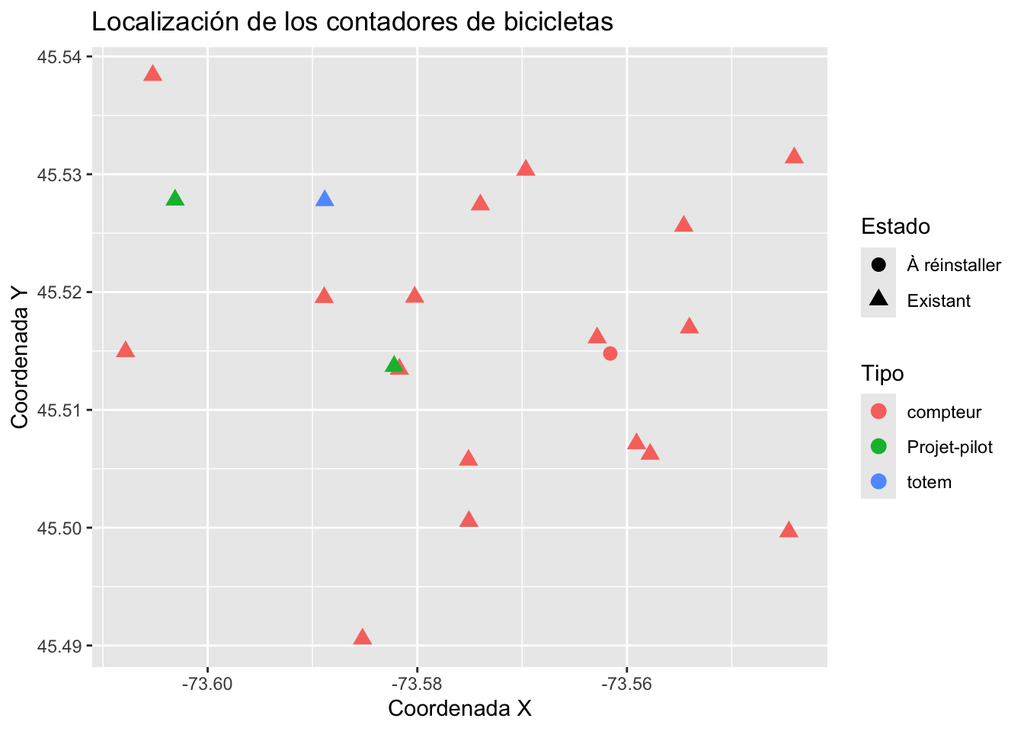

```r
ggplot(
  localizacion,
  aes(
    x = coord_X,
    y = coord_Y,
    color = Type,
    shape = Etat
  )
) +
  geom_point(size = 3) +
  labs(
    x = "Coordenada X",
    y = "Coordenada Y",
    color = "Tipo",
    shape = "Estado",
    title = "Localización de los contadores de bicicletas"
  )
```

# Ejercicio 18

Realizar un join entre los dos dataframes mediante el nombre del distrito y `nom_comptage`.

```r
datos_join <- total_distrito %>%
  left_join(
    localizacion,
    by = c("distrito" = "nom_comptage")
  )

glimpse(datos_join)
```

```
## Rows: 19
## Columns: 9
## $ distrito        <chr> "Berri1", "Boyer", "Boyer 2", "Brébeuf", "CSC (Côte Sa…
## $ total_ciclistas <dbl> 924499, 635273, 470098, 786729, 449665, 204327, 596706…
## $ id              <dbl> 3, 29, NA, 2, NA, NA, NA, 5, 17, 19, 22, 12, 10, 23, 6…
## $ nom             <chr> "Berri_1", "Boyer_1", NA, "Brebeuf_1", NA, NA, NA, "Ma…
## $ Etat            <chr> "Existant", "Existant", NA, "Existant", NA, NA, NA, "E…
## $ Type            <chr> "compteur", "compteur", NA, "compteur", NA, NA, NA, "c…
## $ Annee_implante  <dbl> 2008, 2013, NA, 2009, NA, NA, NA, 2008, 2013, 2013, 20…
## $ coord_X         <dbl> -73.56284, -73.60523, NA, -73.57398, NA, NA, NA, -73.5…
## $ coord_Y         <dbl> 45.51613, 45.53840, NA, 45.52741, NA, NA, NA, 45.50054…
```

# Ejercicio 19

Identificar los distritos del primer dataframe que no se encuentran en el segundo.

```r
distritos_sin_localizacion <- total_distrito %>%
  anti_join(
    localizacion,
    by = c("distrito" = "nom_comptage")
  )

distritos_sin_localizacion
```

```
## # A tibble: 5 × 2
##   distrito                    total_ciclistas
##   <chr>                                 <dbl>
## 1 Boyer 2                              470098
## 2 CSC (Côte Sainte-Catherine)          449665
## 3 Christophe-Colomb                    204327
## 4 Eco-Totem - Métro Laurier            596706
## 5 Saint-Laurent/Bellechasse           1483908
```

Los distritos que no se encuentran en el segundo dataframe son Boyer 2, CSC (Côte Sainte-Catherine), Christophe-Colomb, Eco-Totem - Métro Laurier y Saint-Laurent/Bellechasse.

# Ejercicio 20

Representar las coordenadas de los contadores utilizando el tamaño de los puntos para representar el número total de ciclistas.

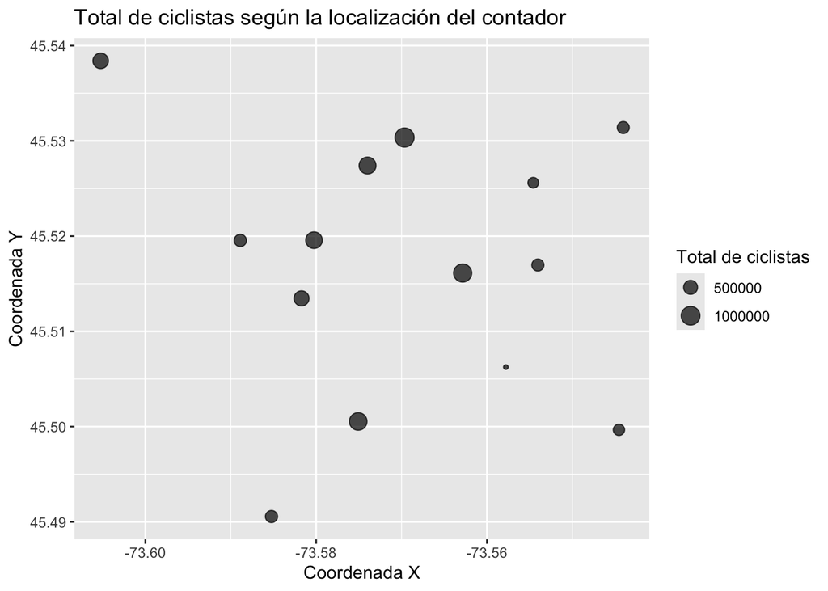

```r
ggplot(
  datos_join,
  aes(
    x = coord_X,
    y = coord_Y,
    size = total_ciclistas
  )
) +
  geom_point(alpha = 0.7, na.rm = TRUE) +
  labs(
    x = "Coordenada X",
    y = "Coordenada Y",
    size = "Total de ciclistas",
    title = "Total de ciclistas según la localización del contador"
  )
```